# Data Cleaning with R

Machocho Mengo

3/1/2020

## Reading the Data

Loading the necessary packages

```r
library(dplyr)
```

Loading the data from the CSV file

```r
advertising <- read.csv("~/Downloads/advertising.csv")
adverts <- as.data.frame(advertising)
```

Previewing the first rows of the dataset

```r
head(adverts)
```

```
##   Daily.Time.Spent.on.Site Age Area.Income Daily.Internet.Usage
## 1                    68.95  35    61833.90               256.09
## 2                    80.23  31    68441.85               193.77
## 3                    69.47  26    59785.94               236.50
## 4                    74.15  29    54806.18               245.89
## 5                    68.37  35    73889.99               225.58
## 6                    59.99  23    59761.56               226.74
##                           Ad.Topic.Line           City Male    Country
## 1    Cloned 5thgeneration orchestration    Wrightburgh    0    Tunisia
## 2    Monitored national standardization      West Jodi    1      Nauru
## 3      Organic bottom-line service-desk       Davidton    0 San Marino
## 4 Triple-buffered reciprocal time-frame West Terrifurt    1      Italy
## 5         Robust logistical utilization   South Manuel    0    Iceland
## 6       Sharable client-driven software      Jamieberg    1     Norway
##             Timestamp Clicked.on.Ad
## 1 2016-03-27 00:53:11             0
## 2 2016-04-04 01:39:02             0
## 3 2016-03-13 20:35:42             0
## 4 2016-01-10 02:31:19             0
## 5 2016-06-03 03:36:18             0
## 6 2016-05-19 14:30:17             0
```

Previewing the last observations of the dataset

```r
tail(adverts)
```

```
##      Daily.Time.Spent.on.Site Age Area.Income Daily.Internet.Usage
## 995                     43.70  28    63126.96               173.01
## 996                     72.97  30    71384.57               208.58
## 997                     51.30  45    67782.17               134.42
## 998                     51.63  51    42415.72               120.37
## 999                     55.55  19    41920.79               187.95
## 1000                    45.01  26    29875.80               178.35
##                             Ad.Topic.Line          City Male
## 995         Front-line bifurcated ability  Nicholasland    0
## 996         Fundamental modular algorithm     Duffystad    1
## 997       Grass-roots cohesive monitoring   New Darlene    1
## 998          Expanded intangible solution South Jessica    1
## 999  Proactive bandwidth-monitored policy   West Steven    0
## 1000      Virtual 5thgeneration emulation   Ronniemouth    0
##                     Country           Timestamp Clicked.on.Ad
## 995                 Mayotte 2016-04-04 03:57:48             1
## 996                 Lebanon 2016-02-11 21:49:00             1
## 997  Bosnia and Herzegovina 2016-04-22 02:07:01             1
## 998                Mongolia 2016-02-01 17:24:57             1
## 999               Guatemala 2016-03-24 02:35:54             0
## 1000                 Brazil 2016-06-03 21:43:21             1
```

Next, we check the structure of the dataset to see the datatypes and shape of the dataset.

```r
str(adverts)
```

```
## 'data.frame':    1000 obs. of  10 variables:
##  $ Daily.Time.Spent.on.Site: num  69 80.2 69.5 74.2 68.4 ...
##  $ Age                     : int  35 31 26 29 35 23 33 48 30 20 ...
##  $ Area.Income             : num  61834 68442 59786 54806 73890 ...
##  $ Daily.Internet.Usage    : num  256 194 236 246 226 ...
##  $ Ad.Topic.Line           : Factor w/ 1000 levels "Adaptive 24hour Graphic Interface",..: 92 465 567 904 767 806 223 724 108 455 ...
##  $ City                    : Factor w/ 969 levels "Adamsbury","Adamside",..: 962 904 112 940 806 283 47 672 885 713 ...
##  $ Male                    : int  0 1 0 1 0 1 0 1 1 1 ...
##  $ Country                 : Factor w/ 237 levels "Afghanistan",..: 216 148 185 104 97 159 146 13 83 79 ...
##  $ Timestamp               : Factor w/ 1000 levels "2016-01-01 02:52:10",..: 440 475 368 57 768 690 131 334 549 942 ...
##  $ Clicked.on.Ad           : int  0 0 0 0 0 0 0 1 0 0 ...
```

The output above showing the datatypes of the different columns. The dtype for the timestamp will be changed to datetime THe dtype for the City variable will be changed to string The dataset has 10 columns and 1000 rows

## Data Cleaning

### COMPLETENESS

Checking for missing values

```r
is.na(adverts)
```

[output not shown]

[output cut: 1987 more lines]

```r
colSums(is.na(adverts))
```

```
## Daily.Time.Spent.on.Site                      Age              Area.Income
##                        0                        0                        0
##     Daily.Internet.Usage            Ad.Topic.Line                     City
##                        0                        0                        0
##                     Male                  Country                Timestamp
##                        0                        0                        0
##            Clicked.on.Ad
##                        0
```

This dataset has no missing values. It is complete.

### CONSISTENCY

Duplicates

```r
duplicated(adverts)
```

[output not shown]

[output cut: 69 more lines]

This datset has no duplicates either! Seems like the dataset gods have been kind to us :-)

UNIQUE VALUES

```r
unique(adverts)
```

```
##      Daily.Time.Spent.on.Site Age Area.Income Daily.Internet.Usage
## 1                       68.95  35    61833.90               256.09
## 2                       80.23  31    68441.85               193.77
## 3                       69.47  26    59785.94               236.50
## 4                       74.15  29    54806.18               245.89
## 5                       68.37  35    73889.99               225.58
## 6                       59.99  23    59761.56               226.74
## 7                       88.91  33    53852.85               208.36
## 8                       66.00  48    24593.33               131.76
## 9                       74.53  30    68862.00               221.51
## 10                      69.88  20    55642.32               183.82
## 11                      47.64  49    45632.51               122.02
## 12                      83.07  37    62491.01               230.87
## 13                      69.57  48    51636.92               113.12
## 14                      79.52  24    51739.63               214.23
```

[output cut: 4990 more lines]

OUTLIERS Let us first remind ourselves of the columns in our dataset.

```r
colnames(adverts, do.NULL = TRUE, prefix = "col")
```

```
##  [1] "Daily.Time.Spent.on.Site" "Age"
##  [3] "Area.Income"              "Daily.Internet.Usage"
##  [5] "Ad.Topic.Line"            "City"
##  [7] "Male"                     "Country"
##  [9] "Timestamp"                "Clicked.on.Ad"
```

BOXPLOT We use boxplots to visualize the outliers

```r
num_cols <- adverts[, c("Daily.Time.Spent.on.Site", "Age", "Area.Income", "Daily.Internet.Usage")]
num_cols
```

```
##      Daily.Time.Spent.on.Site Age Area.Income Daily.Internet.Usage
## 1                       68.95  35    61833.90               256.09
## 2                       80.23  31    68441.85               193.77
## 3                       69.47  26    59785.94               236.50
## 4                       74.15  29    54806.18               245.89
## 5                       68.37  35    73889.99               225.58
## 6                       59.99  23    59761.56               226.74
## 7                       88.91  33    53852.85               208.36
## 8                       66.00  48    24593.33               131.76
## 9                       74.53  30    68862.00               221.51
## 10                      69.88  20    55642.32               183.82
## 11                      47.64  49    45632.51               122.02
## 12                      83.07  37    62491.01               230.87
## 13                      69.57  48    51636.92               113.12
## 14                      79.52  24    51739.63               214.23
```

[output cut: 986 more lines]

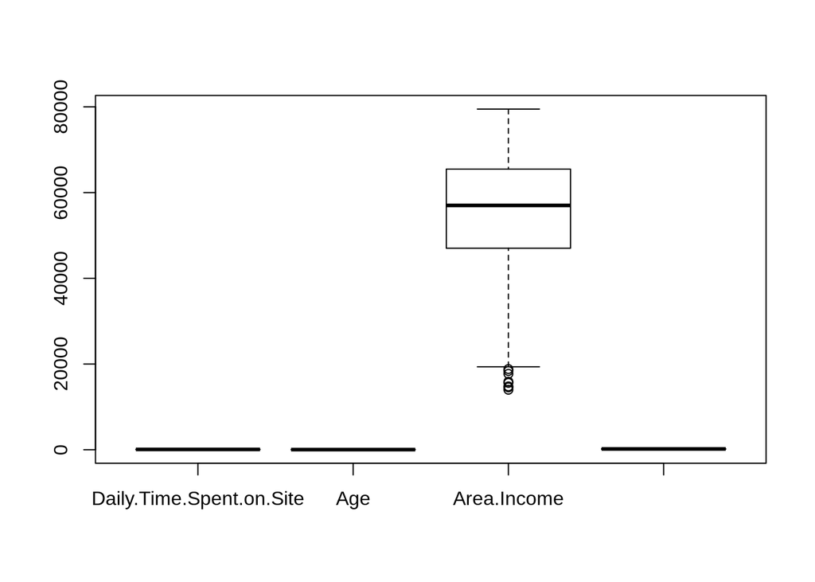

```r
boxplot(num_cols)
```

Outliers are present in the Area.Income. We can investigate further using the IQR test to see how to handle the outliers.

IQR

```r
area_income <- adverts[, c("Area.Income")]
area_income
```

```
##    [1] 61833.90 68441.85 59785.94 54806.18 73889.99 59761.56 53852.85 24593.33
##    [9] 68862.00 55642.32 45632.51 62491.01 51636.92 51739.63 30976.00 52182.23
##   [17] 23936.86 71511.08 31087.54 23821.72 64802.33 60015.57 32635.70 61628.72
##   [25] 68962.32 64828.00 38067.08 58295.82 32708.94 46179.97 51473.28 45593.93
##   [33] 25583.29 30227.98 45580.92 61389.50 56770.79 76435.30 57425.87 27508.41
##   [41] 57691.95 59784.18 66572.39 64929.61 57519.64 53575.48 50983.75 67058.72
##   [49] 52723.34 54286.10 61526.25 58526.04 53350.11 62657.53 62722.57 67479.62
##   [57] 75254.88 52336.64 56113.37 24852.90 47708.42 64654.66 71228.44 61601.05
##   [65] 66281.46 73910.90 51317.33 51510.18 61005.87 32536.98 60248.97 74543.81
##   [73] 75509.61 42650.32 58183.04 60465.72 57009.76 54541.56 32689.04 55605.92
##   [81] 63296.87 65653.47 61652.53 30726.26 74535.94 47861.93 73600.28 58543.94
##   [89] 42696.67 37334.78 71392.53 59550.05 64264.25 64147.86 25686.34 52968.22
##   [97] 22473.08 64927.19 51868.85 69456.83 31947.65 51864.77 59593.56 48376.14
##  [105] 56884.74 67186.54 46557.92 66541.05 33258.09 72272.90 60333.38 65229.13
##  [113] 56067.38 37838.72 72683.35 56729.78 66815.54 60223.52 29727.79 49269.98
```

[output cut: 110 more lines]

```r
iqr_AI <- IQR(area_income)
iqr_AI
```

```
## [1] 18438.83
```

Visualizing the column using boxplot

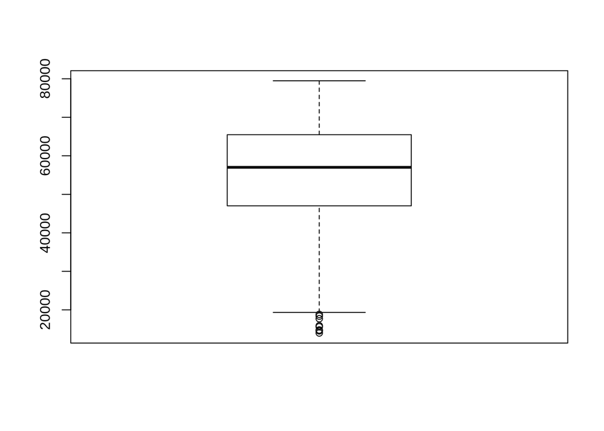

```r
boxplot(area_income)
```

Discarding the Outliers

```r
summary(area_income)
```

```
##    Min. 1st Qu.  Median    Mean 3rd Qu.    Max.
##   13996   47032   57012   55000   65471   79485
```

We will use the 1st quartile to set the benchmark for the minimum value.

```r
benchmark <- 47032 - 1.5*18438.8325
benchmark
```

```
## [1] 19373.75
```

Our benchmark value is set. Any value below the value will be considered an outlier and so it will be discarded from the dataset.

```r
area_income <- area_income[area_income > benchmark]

summary(area_income)
```

```
##    Min. 1st Qu.  Median    Mean 3rd Qu.    Max.
##   19992   47348   57260   55349   65538   79485
```

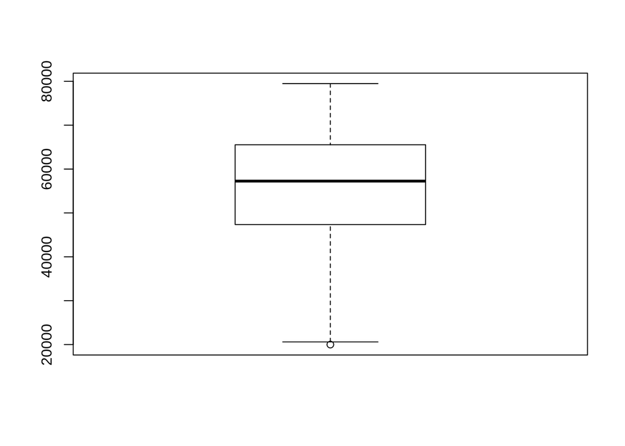

```r
boxplot(area_income)
```

### UNIFORMITY

Changing TimeStamp variable to Date type. We first split the variable into two columns: DATE and TIME Then we apply the as.Date() function to change the datatypes to Date and as.Time() Let us remind ourselves of the dataset

```r
head(adverts)
```

```
##   Daily.Time.Spent.on.Site Age Area.Income Daily.Internet.Usage
## 1                    68.95  35    61833.90               256.09
## 2                    80.23  31    68441.85               193.77
## 3                    69.47  26    59785.94               236.50
## 4                    74.15  29    54806.18               245.89
## 5                    68.37  35    73889.99               225.58
## 6                    59.99  23    59761.56               226.74
##                           Ad.Topic.Line           City Male    Country
## 1    Cloned 5thgeneration orchestration    Wrightburgh    0    Tunisia
## 2    Monitored national standardization      West Jodi    1      Nauru
## 3      Organic bottom-line service-desk       Davidton    0 San Marino
## 4 Triple-buffered reciprocal time-frame West Terrifurt    1      Italy
## 5         Robust logistical utilization   South Manuel    0    Iceland
## 6       Sharable client-driven software      Jamieberg    1     Norway
##             Timestamp Clicked.on.Ad
## 1 2016-03-27 00:53:11             0
## 2 2016-04-04 01:39:02             0
## 3 2016-03-13 20:35:42             0
## 4 2016-01-10 02:31:19             0
## 5 2016-06-03 03:36:18             0
## 6 2016-05-19 14:30:17             0
```

To load the package we need for the process of splitting the column and changing the data type.

```r
library(tidyr)
```

#### TIMESTAMP

Splitting the column into Date and Time

```r
adverts_2 <- separate(data = adverts, col = Timestamp, into = c("Date", "Time"), sep = " ")
head(adverts_2)
```

```
##   Daily.Time.Spent.on.Site Age Area.Income Daily.Internet.Usage
## 1                    68.95  35    61833.90               256.09
## 2                    80.23  31    68441.85               193.77
## 3                    69.47  26    59785.94               236.50
## 4                    74.15  29    54806.18               245.89
## 5                    68.37  35    73889.99               225.58
## 6                    59.99  23    59761.56               226.74
##                           Ad.Topic.Line           City Male    Country
## 1    Cloned 5thgeneration orchestration    Wrightburgh    0    Tunisia
## 2    Monitored national standardization      West Jodi    1      Nauru
## 3      Organic bottom-line service-desk       Davidton    0 San Marino
## 4 Triple-buffered reciprocal time-frame West Terrifurt    1      Italy
## 5         Robust logistical utilization   South Manuel    0    Iceland
## 6       Sharable client-driven software      Jamieberg    1     Norway
##         Date     Time Clicked.on.Ad
## 1 2016-03-27 00:53:11             0
## 2 2016-04-04 01:39:02             0
## 3 2016-03-13 20:35:42             0
## 4 2016-01-10 02:31:19             0
## 5 2016-06-03 03:36:18             0
## 6 2016-05-19 14:30:17             0
```

Let us check the datatypes of the new columns

```r
str(adverts_2)
```

```
## 'data.frame':    1000 obs. of  11 variables:
##  $ Daily.Time.Spent.on.Site: num  69 80.2 69.5 74.2 68.4 ...
##  $ Age                     : int  35 31 26 29 35 23 33 48 30 20 ...
##  $ Area.Income             : num  61834 68442 59786 54806 73890 ...
##  $ Daily.Internet.Usage    : num  256 194 236 246 226 ...
##  $ Ad.Topic.Line           : Factor w/ 1000 levels "Adaptive 24hour Graphic Interface",..: 92 465 567 904 767 806 223 724 108 455 ...
##  $ City                    : Factor w/ 969 levels "Adamsbury","Adamside",..: 962 904 112 940 806 283 47 672 885 713 ...
##  $ Male                    : int  0 1 0 1 0 1 0 1 1 1 ...
##  $ Country                 : Factor w/ 237 levels "Afghanistan",..: 216 148 185 104 97 159 146 13 83 79 ...
##  $ Date                    : chr  "2016-03-27" "2016-04-04" "2016-03-13" "2016-01-10" ...
##  $ Time                    : chr  "00:53:11" "01:39:02" "20:35:42" "02:31:19" ...
##  $ Clicked.on.Ad           : int  0 0 0 0 0 0 0 1 0 0 ...
```

```r
adverts_2$Date <- as.Date(adverts_2$Date, format = "%Y-%m-%d")

adverts_2$Time <- as.Date(adverts_2$Time, format = "%h-%m-$s")
```

#### MALE, CLICKED ON AD, CITY, COUNTRY AND AD TOPIC LINE

We change the first two variables into factor as they are categorical variables and the 3 into characters

```r
#changing the datatypes into factors
adverts_2$Male <- as.factor(adverts_2$Male)
adverts_2$Clicked.on.Ad <- as.factor(adverts_2$Clicked.on.Ad)

#changing datatypes into characters
adverts_2$City <- as.character(adverts_2$City)
adverts_2$Country <- as.character(adverts_2$Country)
adverts_2$Ad.Topic.Line <- as.character(adverts_2$Ad.Topic.Line)

str(adverts_2)
```

```
## 'data.frame':    1000 obs. of  11 variables:
##  $ Daily.Time.Spent.on.Site: num  69 80.2 69.5 74.2 68.4 ...
##  $ Age                     : int  35 31 26 29 35 23 33 48 30 20 ...
##  $ Area.Income             : num  61834 68442 59786 54806 73890 ...
##  $ Daily.Internet.Usage    : num  256 194 236 246 226 ...
##  $ Ad.Topic.Line           : chr  "Cloned 5thgeneration orchestration" "Monitored national standardization" "Organic bottom-line service-desk" "Triple-buffered reciprocal time-frame" ...
##  $ City                    : chr  "Wrightburgh" "West Jodi" "Davidton" "West Terrifurt" ...
##  $ Male                    : Factor w/ 2 levels "0","1": 1 2 1 2 1 2 1 2 2 2 ...
##  $ Country                 : chr  "Tunisia" "Nauru" "San Marino" "Italy" ...
##  $ Date                    : Date, format: "2016-03-27" "2016-04-04" ...
##  $ Time                    : Date, format: NA NA ...
##  $ Clicked.on.Ad           : Factor w/ 2 levels "0","1": 1 1 1 1 1 1 1 2 1 1 ...
```

## UNIVARIATE ANALYSIS

This is the analysis and visualization of individual variables of a dataset.

### Daily.Time.Spent.on.Site

First, let us get the measures of dispersion and central tendencies

#### Measures of Central Tendencies

```r
#getting the artithmetic mean of the variable
mean_1 <- mean(adverts_2$Daily.Time.Spent.on.Site)
mean_1
```

```
## [1] 65.0002
```

```r
#getting the median of the variable
meadian_1 <- median(adverts_2$Daily.Time.Spent.on.Site)
meadian_1
```

```
## [1] 68.215
```

```r
#creating a fxn for getting the mode
getmode <- function(v) {
   uniqv <- unique(v)
   uniqv[which.max(tabulate(match(v, uniqv)))]
}

mode_1 <- getmode(adverts_2$Daily.Time.Spent.on.Site)
mode_1
```

```
## [1] 62.26
```

#### Measures of Dispersion

```r
#Getting the minimum value of the variable
min_1 <- min(adverts_2$Daily.Time.Spent.on.Site)
min_1
```

```
## [1] 32.6
```

```r
#getting the maximum value of the variable
max_1 <- max(adverts_2$Daily.Time.Spent.on.Site)
max_1
```

```
## [1] 91.43
```

```r
#Getting thw range of the variable
range_1 <- range(adverts_2$Daily.Time.Spent.on.Site)
range_1
```

```
## [1] 32.60 91.43
```

```r
#getting the quantiles of the variable
quantiles_1 <- quantile(adverts_2$Daily.Time.Spent.on.Site)
quantiles_1
```

```
##      0%     25%     50%     75%    100%
## 32.6000 51.3600 68.2150 78.5475 91.4300
```

```r
#getting the  variable of the varibale
var_1 <- var(adverts_2$Daily.Time.Spent.on.Site)
var_1
```

```
## [1] 251.3371
```

```r
#getting the standard deviation of the variable
std_1 <- sd(adverts_2$Daily.Time.Spent.on.Site)
std_1
```

```
## [1] 15.85361
```

#### Visualizations

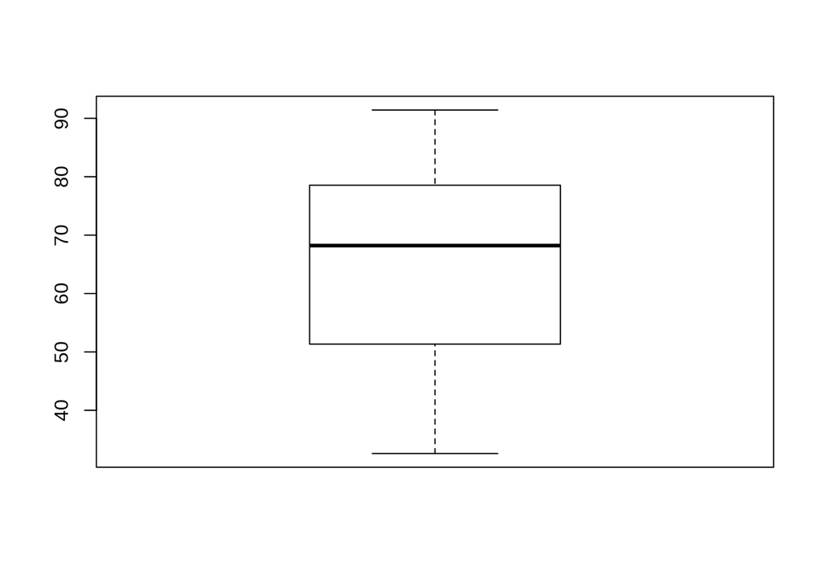

```r
#vizualization using boxplot
boxplot(adverts_2$Daily.Time.Spent.on.Site)
```

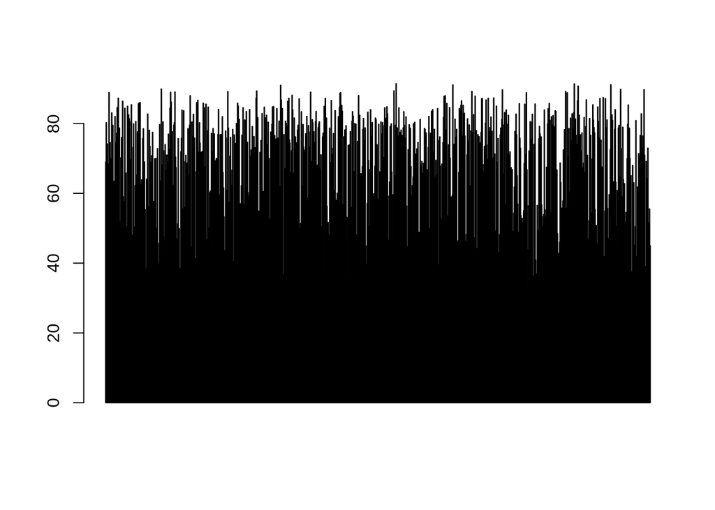

```r
#visualization using the bar graphs approach
barplot(adverts_2$Daily.Time.Spent.on.Site)
```

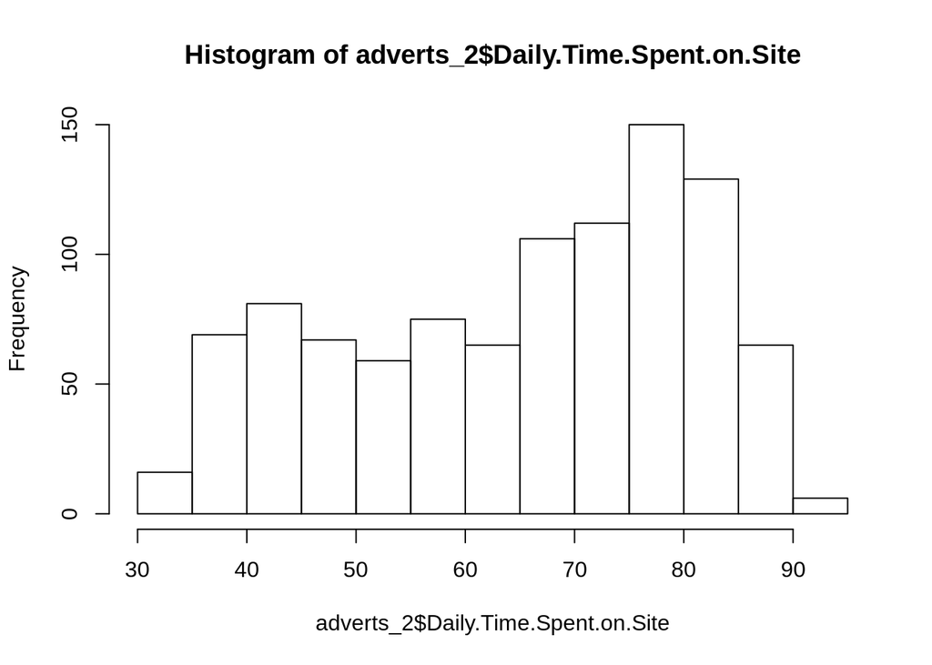

```r
#visualization using histograms
hist(adverts_2$Daily.Time.Spent.on.Site)
```

### AGE

#### Measures of Central Tendencies

```r
#getting the artithmetic mean of the variable
mean_2 <- mean(adverts_2$Age)
mean_2
```

```
## [1] 36.009
```

```r
#getting the median of the variable
meadian_2 <- median(adverts_2$Age)
meadian_2
```

```
## [1] 35
```

```r
#creating a fxn for getting the mode
getmode <- function(v) {
   uniqv <- unique(v)
   uniqv[which.max(tabulate(match(v, uniqv)))]
}

mode_2 <- getmode(adverts_2$Age)
mode_2
```

```
## [1] 31
```

#### Measures of Dispersion

```r
#Getting the minimum value of the variable
min_2 <- min(adverts_2$Age)
min_2
```

```
## [1] 19
```

```r
#getting the maximum value of the variable
max_2 <- max(adverts_2$Age)
max_2
```

```
## [1] 61
```

```r
#Getting thw range of the variable
range_2 <- range(adverts_2$Age)
range_2
```

```
## [1] 19 61
```

```r
#getting the quantiles of the variable
quantiles_2 <- quantile(adverts_2$Age)
quantiles_2
```

```
##   0%  25%  50%  75% 100%
##   19   29   35   42   61
```

```r
#getting the  variable of the varibale
var_2 <- var(adverts_2$Age)
var_2
```

```
## [1] 77.18611
```

```r
#getting the standard deviation of the variable
std_2 <- sd(adverts_2$Age)
std_2
```

```
## [1] 8.785562
```

#### Visualizations

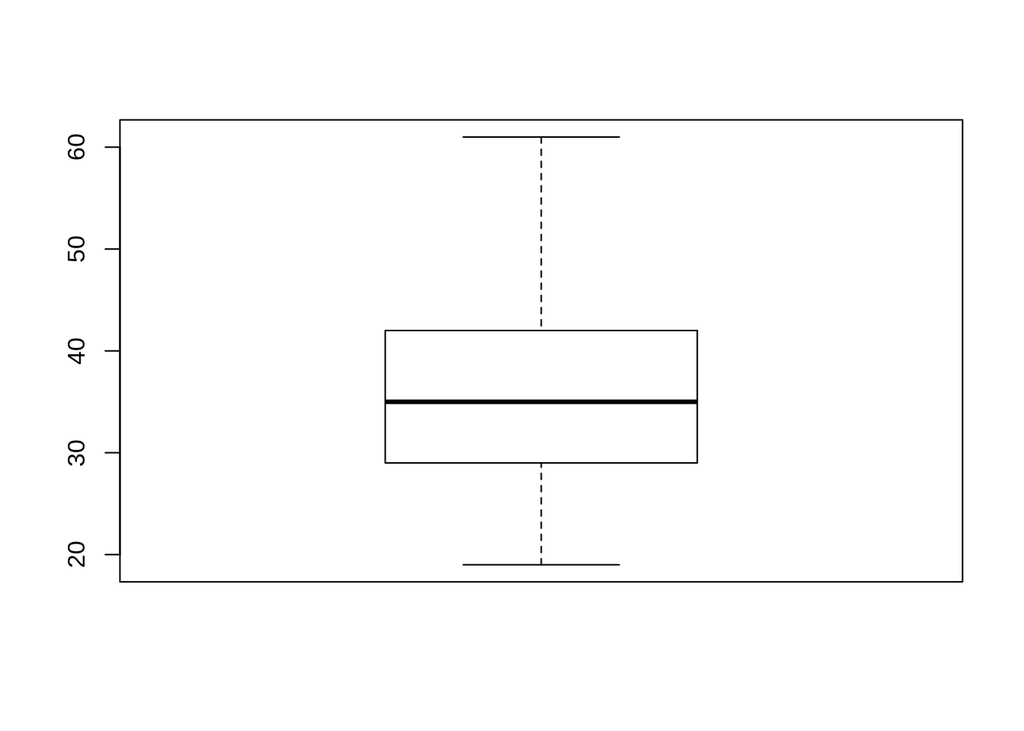

```r
#vizualization using boxplot
boxplot(adverts_2$Age)
```

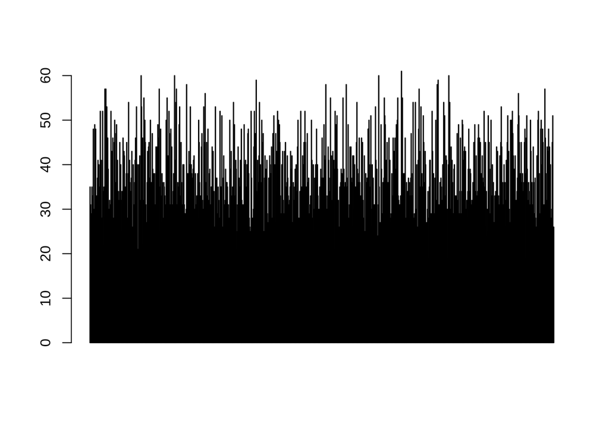

```r
#visualization using the bar graphs approach
barplot(adverts_2$Age)
```

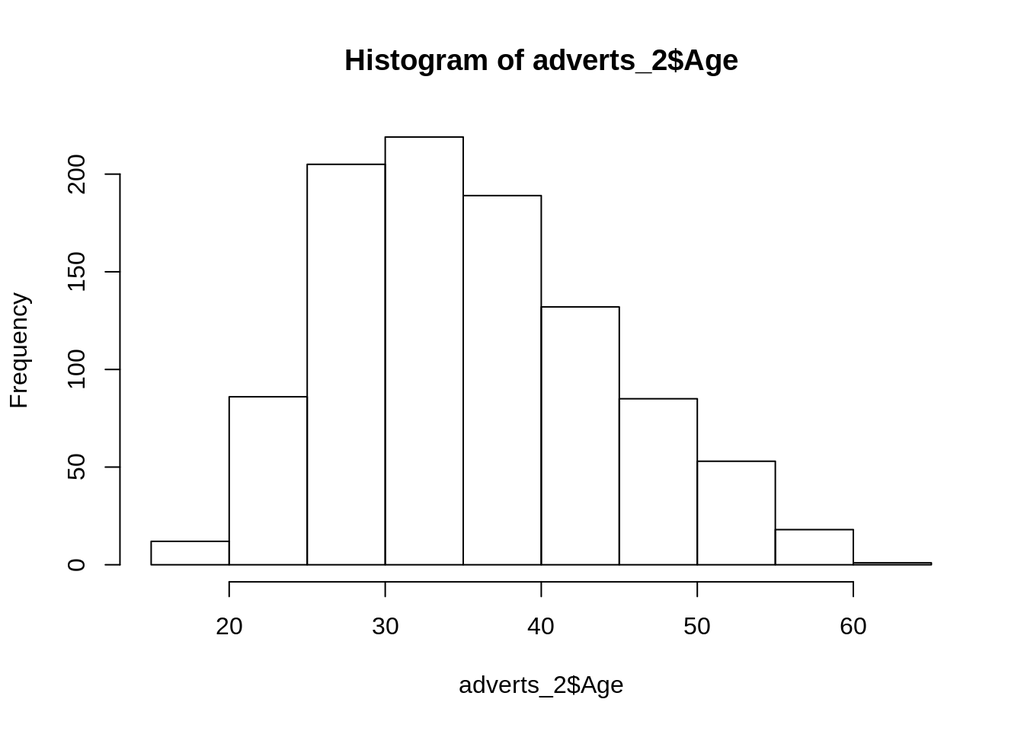

```r
#visualization using histograms
hist(adverts_2$Age)
```

### AREA.INCOME

#### Measures of Central Tendencies

```r
#getting the artithmetic mean of the variable
mean_3 <- mean(adverts_2$Area.Income)
mean_3
```

```
## [1] 55000
```

```r
#getting the median of the variable
meadian_3 <- median(adverts_2$Area.Income)
meadian_3
```

```
## [1] 57012.3
```

```r
#creating a fxn for getting the mode
getmode <- function(v) {
   uniqv <- unique(v)
   uniqv[which.max(tabulate(match(v, uniqv)))]
}

mode_3 <- getmode(adverts_2$Area.Income)
mode_3
```

```
## [1] 61833.9
```

#### Measures of Dispersion

```r
#Getting the minimum value of the variable
min_3 <- min(adverts_2$Area.Income)
min_3
```

```
## [1] 13996.5
```

```r
#getting the maximum value of the variable
max_3 <- max(adverts_2$Area.Income)
max_3
```

```
## [1] 79484.8
```

```r
#Getting thw range of the variable
range_3 <- range(adverts_2$Area.Income)
range_3
```

```
## [1] 13996.5 79484.8
```

```r
#getting the quantiles of the variable
quantiles_3 <- quantile(adverts_2$Area.Income)
quantiles_3
```

```
##       0%      25%      50%      75%     100%
## 13996.50 47031.80 57012.30 65470.64 79484.80
```

```r
#getting the  variable of the varibale
var_3 <- var(adverts_2$Area.Income)
var_3
```

```
## [1] 179952406
```

```r
#getting the standard deviation of the variable
std_3 <- sd(adverts_2$Area.Income)
std_3
```

```
## [1] 13414.63
```

#### Visualizations

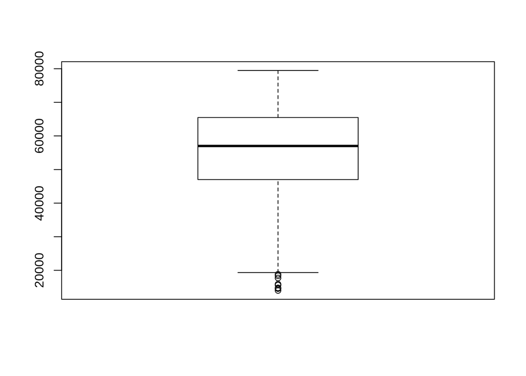

```r
#vizualization using boxplot
boxplot(adverts_2$Area.Income)
```

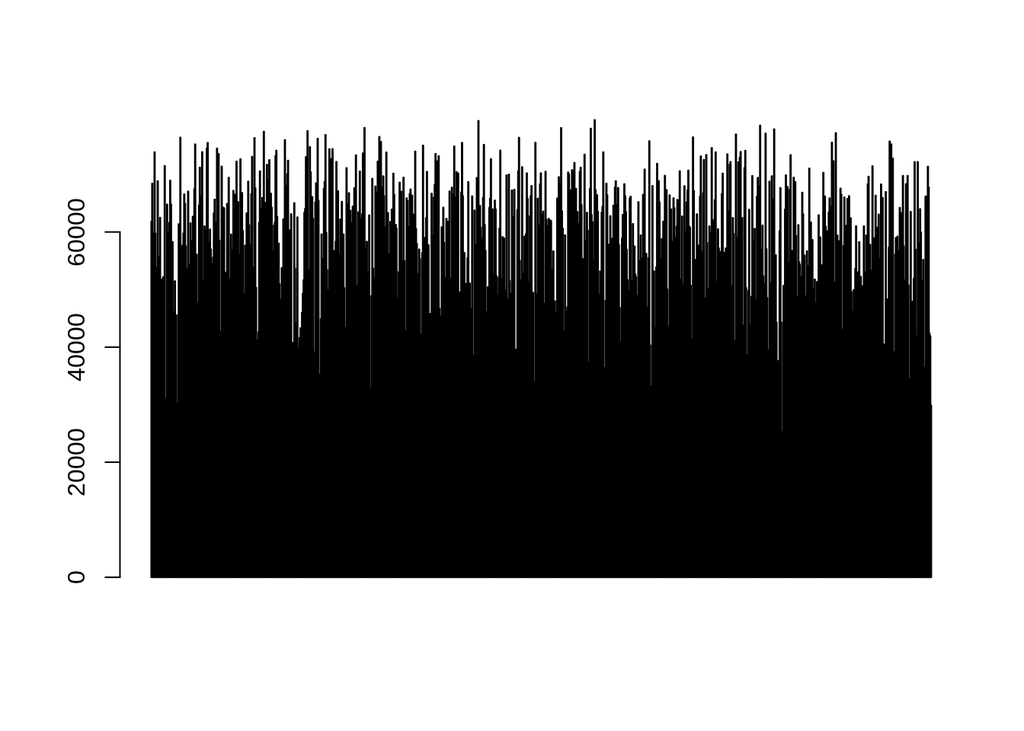

```r
#visualization using the bar graphs approach
barplot(adverts_2$Area.Income)
```

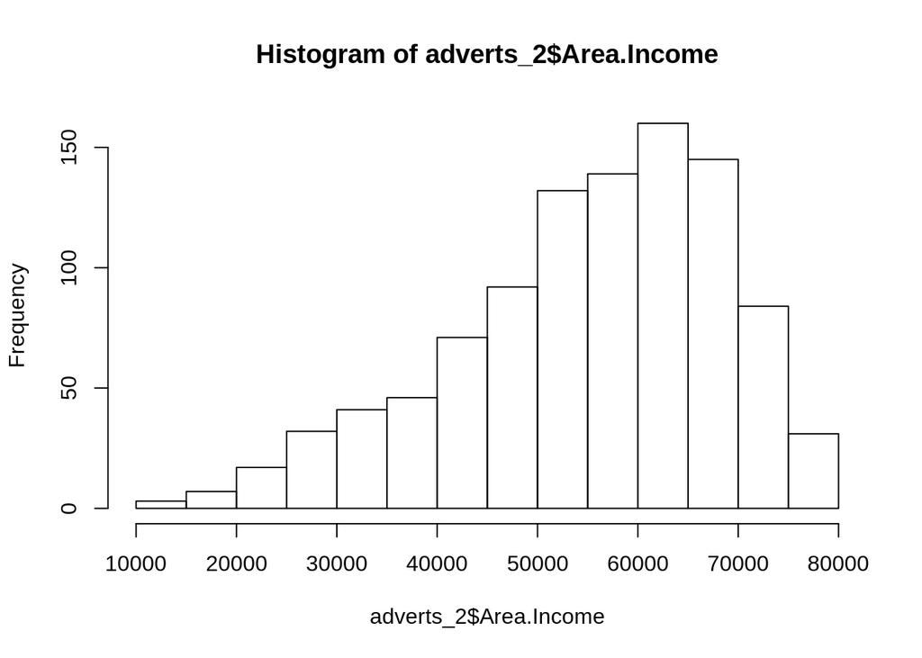

```r
#visualization using histograms
hist(adverts_2$Area.Income)
```

### Daily.Internet.Usage

#### Measures of Central Tendencies

```r
#getting the artithmetic mean of the variable
mean_4 <- mean(adverts_2$Daily.Internet.Usage)
mean_4
```

```
## [1] 180.0001
```

```r
#getting the median of the variable
meadian_4 <- median(adverts_2$Daily.Internet.Usage)
meadian_4
```

```
## [1] 183.13
```

```r
#creating a fxn for getting the mode
getmode <- function(v) {
   uniqv <- unique(v)
   uniqv[which.max(tabulate(match(v, uniqv)))]
}

mode_4 <- getmode(adverts_2$Daily.Internet.Usage)
mode_4
```

```
## [1] 167.22
```

#### Measures of Dispersion

```r
#Getting the minimum value of the variable
min_4 <- min(adverts_2$Daily.Internet.Usage)
min_4
```

```
## [1] 104.78
```

```r
#getting the maximum value of the variable
max_4 <- max(adverts_2$Daily.Internet.Usage)
max_4
```

```
## [1] 269.96
```

```r
#Getting thw range of the variable
range_4 <- range(adverts_2$Daily.Internet.Usage)
range_4
```

```
## [1] 104.78 269.96
```

```r
#getting the quantiles of the variable
quantiles_4 <- quantile(adverts_2$Daily.Internet.Usage)
quantiles_4
```

```
##       0%      25%      50%      75%     100%
## 104.7800 138.8300 183.1300 218.7925 269.9600
```

```r
#getting the  variable of the varibale
var_4 <- var(adverts_2$Daily.Internet.Usage)
var_4
```

```
## [1] 1927.415
```

```r
#getting the standard deviation of the variable
std_4 <- sd(adverts_2$Daily.Internet.Usage)
std_4
```

```
## [1] 43.90234
```

#### Visualizations

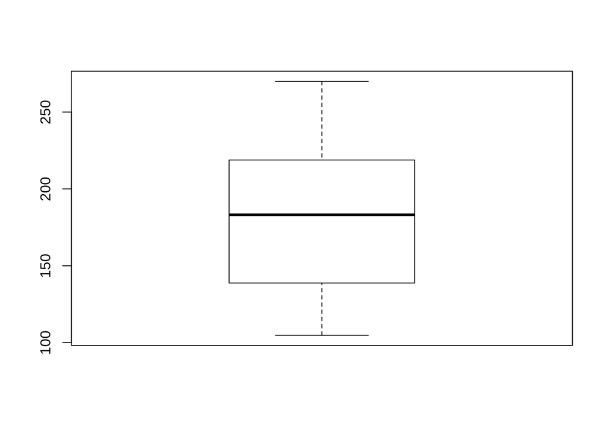

```r
#vizualization using boxplot
boxplot(adverts_2$Daily.Internet.Usage)
```

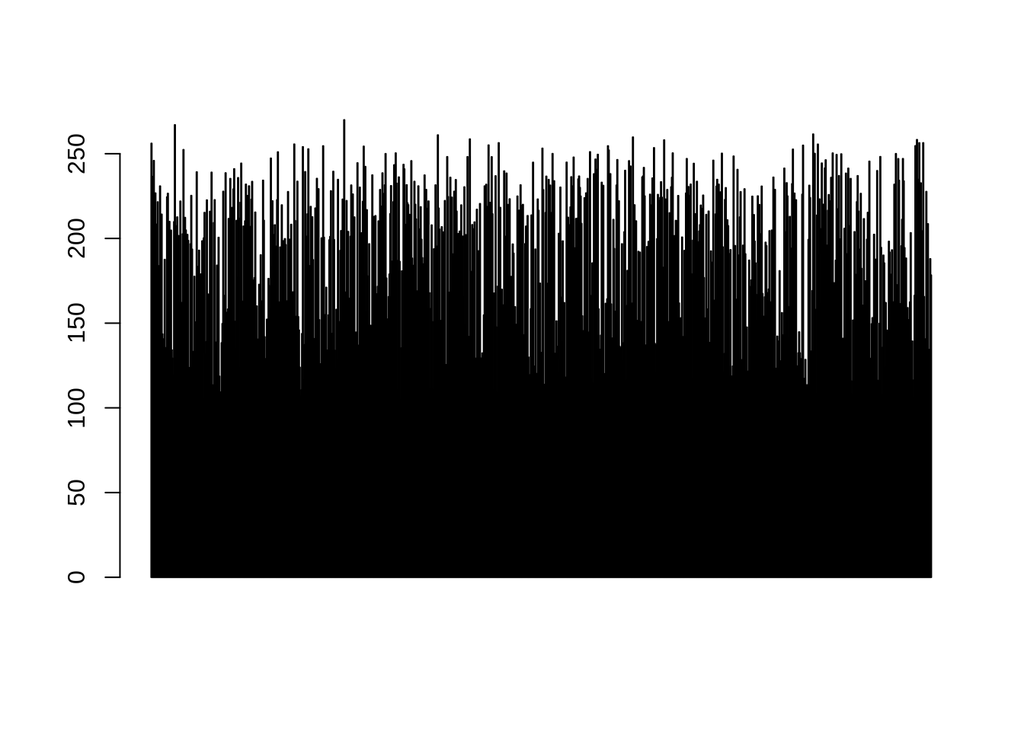

```r
#visualization using the bar graphs approach
barplot(adverts_2$Daily.Internet.Usage)
```

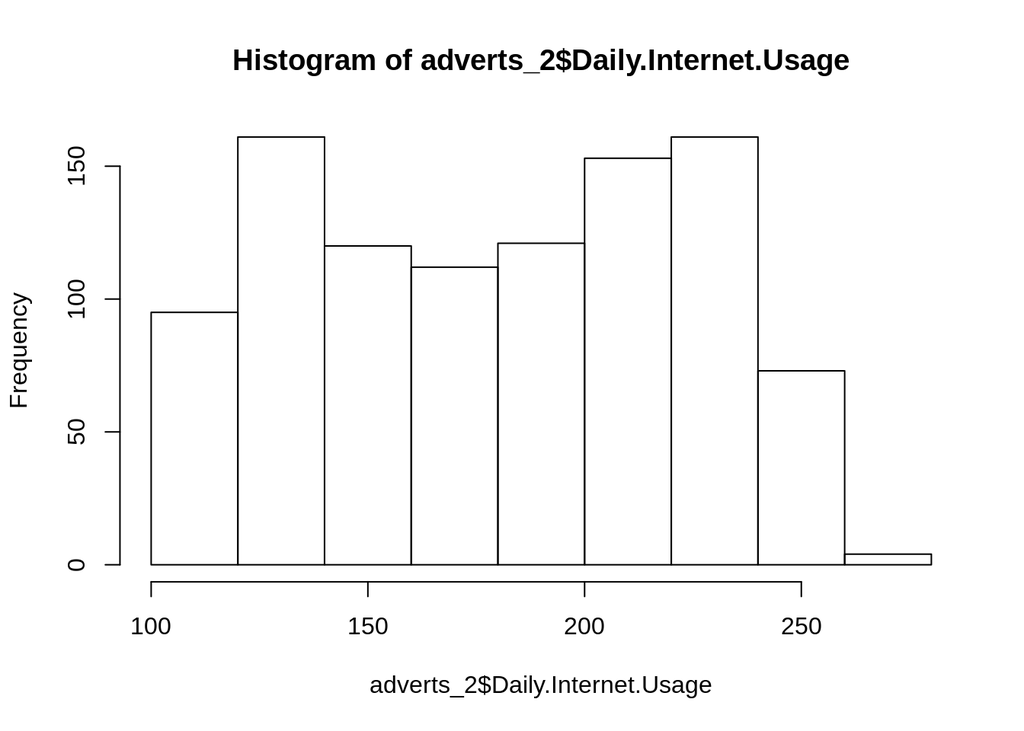

```r
#visualization using histograms
hist(adverts_2$Daily.Internet.Usage)
```

#### Visualizing the Male and Clicked on Ads variables.

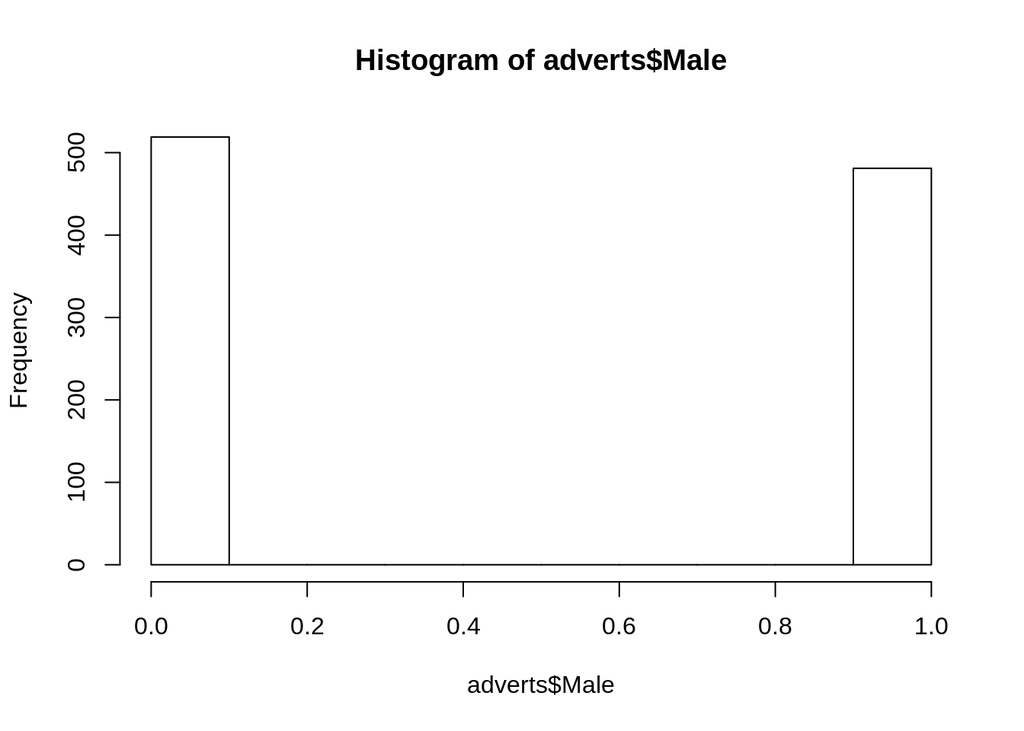

```r
#histogram of the Male variable
hist(adverts$Male)
```

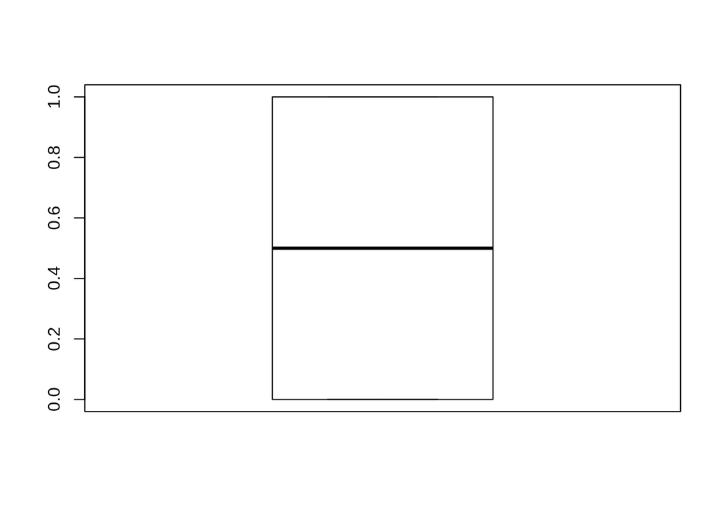

```r
#histogram of the Clicked on Ads variable
boxplot(adverts$Clicked.on.Ad)
```

## BIVARIATE ANALYSIS

### Daily.Time.Spent.on.Site AND Age

```r
Time_s <- adverts_2$Daily.Time.Spent.on.Site
age <- adverts_2$Age

#getting the covariance between the two variables
cov(Time_s, age )
```

```
## [1] -46.17415
```

```r
#getting the ccorrelation coefficient
cor(Time_s, age)
```

```
## [1] -0.3315133
```

```r
#The variables have a negative correlaton coefficient. This means that for an increase in age, there is a -0.3315133 decrease in the time that one spends on the internet. The value is 0.3 which means that the correlation is very small
```

SCATTERPLOTS A scatter plot is a two-dimensional data visualization that uses dots to represent the values obtained for two different variables - one plotted along the x-axis and the other plotted along the y-axis. Scatter plots are used when you want to show the relationship between two variables. They are sometimes called correlation plots because they show how two variables are correlated.

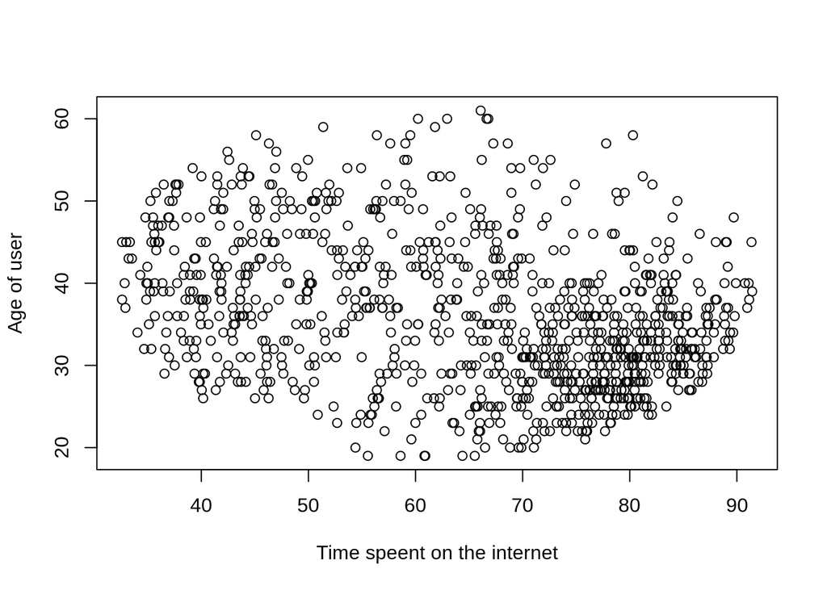

```r
plot(Time_s, age, xlab="Time speent on the internet", ylab="Age of user")
```

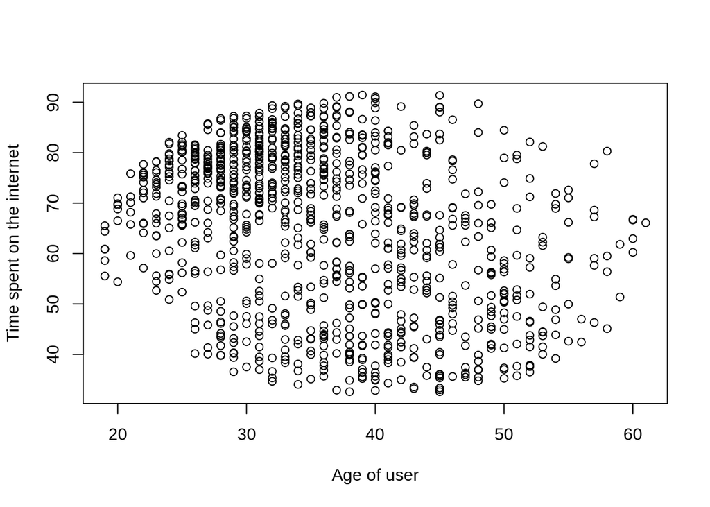

```r
plot(age, Time_s, xlab="Age of user", ylab="Time spent on the internet")
```

### AREA INCOME AND DAILY TIME SPENT ON THE SITE

```r
Time_s <- adverts_2$Daily.Time.Spent.on.Site
income <- adverts_2$Area.Income

#getting the covariance between the two variables
cov(Time_s, income )
```

```
## [1] 66130.81
```

```r
#getting the ccorrelation coefficient
cor(Time_s, income)
```

```
## [1] 0.3109544
```

```r
#there is a positive correlation between the 2 variables. This means that for every unite increase of income made, there is a 0.3109544 increase in time spent on the site. The correlation is weak howerver since the correlation coeficient is less than 0.5
```

SCATTERPLOT

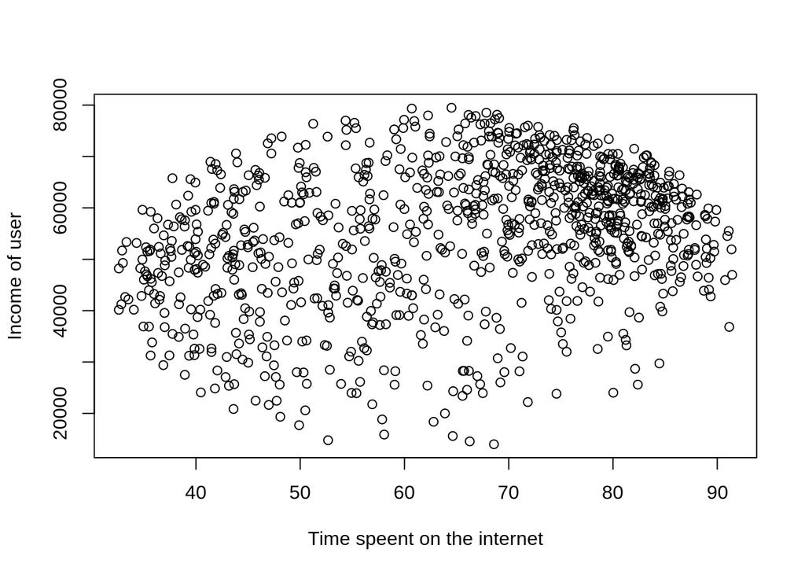

```r
plot(Time_s, income, xlab="Time speent on the internet", ylab="Income of user")
```

### AREA INCOME AND AGE

```r
#getting the covariance between the two variables
cov(age, income )
```

```
## [1] -21520.93
```

```r
#getting the ccorrelation coefficient
cor(age, income)
```

```
## [1] -0.182605
```

```r
#there is a very weak negative correlation between the two variables
```

SCATTERPLOT

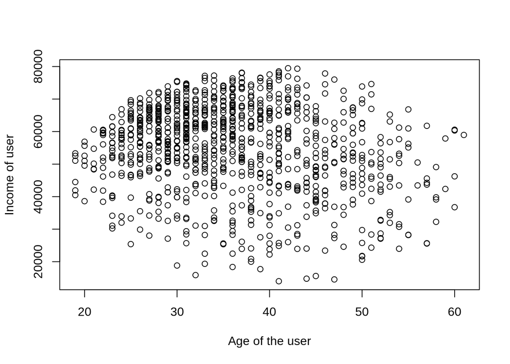

```r
plot(age, income, xlab="Age of the user", ylab="Income of user")
```

### AGE AND DAILY INTERNET USAGE

```r
Daily <- adverts_2$Daily.Internet.Usage

#getting the covaraiance between the 2 variables
cov(age, Daily)
```

```
## [1] -141.6348
```

```r
#getting the correlation coefficient
cor(age, Daily)
```

```
## [1] -0.3672086
```

SCATTERPLOT

[figure not shown]

```r
plot(age, Daily, xlab="Age of the user", ylab="Income of user")
```

### INCOME AND DAILY INTERNET USAGE

```r
#getting the covaraiance between the 2 variables
cov(income, Daily)
```

```
## [1] 198762.5
```

```r
#getting the correlation coefficient
cor(income, Daily)
```

```
## [1] 0.3374955
```

SCATTERPLOT

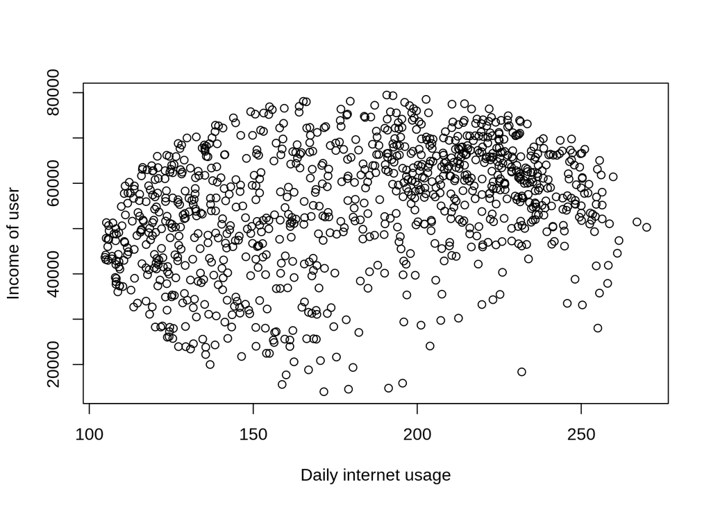

```r
plot(Daily, income, xlab="Daily internet usage", ylab="Income of user")
```